# week4_lab1

yang

July 25, 2018

# 分析前準備

## 讀入資料

```r
dta <- read.table(file = "TIMSS2011TW.txt", header = TRUE)
```

## 查看資料結構與基本統計

該資料包含4467位學生在數學及科學方面的成績、興趣、評價、投入、時間，以及家長教育背景、能獲得的教育資源，共13種變數

```r
str(dta)
```

```
## 'data.frame':    4467 obs. of  13 variables:
##  $ gender               : Factor w/ 2 levels "boy","girl": 2 2 2 2 2 2 2 2 2 2 ...
##  $ math                 : num  729 776 718 607 658 ...
##  $ math.interest        : num  8.93 13.47 9.6 13.47 8.27 ...
##  $ math.evaluation      : num  9.34 9.34 10.35 10.35 8.21 ...
##  $ math.input           : num  9.16 12.42 10.15 8.71 7.86 ...
##  $ math.hours           : Factor w/ 3 levels "<= 45min",">= 3hours",..: 3 1 1 1 3 1 1 3 1 1 ...
##  $ science              : num  683 663 667 575 650 ...
##  $ science.interest     : num  7.65 7.65 9.42 9.42 9.04 ...
##  $ science.evaluation   : num  9.16 6.53 11.09 7.6 8.23 ...
##  $ science.input        : num  8.3 7.92 9.55 7.92 8.7 ...
##  $ science.hours        : Factor w/ 3 levels "<= 45min",">= 3hours",..: 1 1 1 1 1 1 1 1 1 3 ...
##  $ parental.education   : Factor w/ 5 levels "college","elementary school",..: 3 3 2 4 5 1 5 4 3 3 ...
##  $ educational.resources: num  9.6 8.92 6.33 10.25 10.93 ...
```

```r
head(dta)
```

```
##   gender     math math.interest math.evaluation math.input     math.hours
## 1   girl 729.3937       8.93041         9.34439    9.15641 45min - 3hours
## 2   girl 776.1965      13.46507         9.34439   12.42205       <= 45min
## 3   girl 718.1735       9.60333        10.35139   10.15325       <= 45min
## 4   girl 607.1847      13.46507        10.35139    8.70884       <= 45min
## 5   girl 658.1759       8.26761         8.20673    7.85736 45min - 3hours
## 6   girl 478.5763       6.36452         7.27410    7.85736       <= 45min
##    science science.interest science.evaluation science.input science.hours
## 1 682.7541          7.64598            9.15956       8.30491      <= 45min
## 2 663.3682          7.64598            6.52660       7.91938      <= 45min
## 3 667.1151          9.41832           11.09147       9.54897      <= 45min
## 4 575.0923          9.41832            7.60129       7.91938      <= 45min
## 5 649.7578          9.03893            8.23142       8.69954      <= 45min
## 6 491.3467         12.94370            9.15956      10.57281      <= 45min
##   parental.education educational.resources
## 1        high school               9.60097
## 2        high school               8.91919
## 3  elementary school               6.33067
## 4 junior high school              10.25396
## 5   university above              10.92551
## 6            college              10.92551
```

```r
summary(dta)
```

```
##   gender          math       math.interest    math.evaluation
##  boy :2225   Min.   :166.4   Min.   : 5.037   Min.   : 3.412
##  girl:2242   1st Qu.:556.0   1st Qu.: 7.912   1st Qu.: 7.274
##              Median :629.9   Median : 8.930   Median : 8.207
##              Mean   :618.1   Mean   : 9.079   Mean   : 8.357
##              3rd Qu.:687.6   3rd Qu.: 9.965   3rd Qu.: 9.344
##              Max.   :918.1   Max.   :13.465   Max.   :13.707
##    math.input              math.hours      science      science.interest
##  Min.   : 3.265   <= 45min      :1628   Min.   :178.8   Min.   : 4.513
##  1st Qu.: 7.857   >= 3hours     : 803   1st Qu.:517.9   1st Qu.: 7.989
##  Median : 8.584   45min - 3hours:2036   Median :577.5   Median : 9.039
##  Mean   : 8.583                         Mean   :570.6   Mean   : 9.010
##  3rd Qu.: 9.635                         3rd Qu.:627.2   3rd Qu.: 9.827
##  Max.   :14.343                         Max.   :844.3   Max.   :12.944
##  science.evaluation science.input           science.hours
##  Min.   : 4.136     Min.   : 3.556   <= 45min      :2396
##  1st Qu.: 7.601     1st Qu.: 7.524   >= 3hours     : 274
##  Median : 8.540     Median : 8.700   45min - 3hours:1797
##  Mean   : 8.556     Mean   : 8.613
##  3rd Qu.: 9.479     3rd Qu.: 9.549
##  Max.   :13.103     Max.   :13.833
##           parental.education educational.resources
##  college           : 672     Min.   : 4.323
##  elementary school :  78     1st Qu.: 9.601
##  high school       :2021     Median :10.254
##  junior high school: 449     Mean   :10.486
##  university above  :1247     3rd Qu.:11.649
##                              Max.   :14.018
```

## 載入 ggplot2 準備畫圖

```r
library(ggplot2)
require(ggplot2)
#將底下的圖設定為黑白配色（theme_bw）
old <- theme_set(theme_bw())
```

# 資料分析與繪圖

## 性別 vs 數學成績

### boxplot

由盒狀圖中可觀察到:男生與女生數學成績的平均數差異不大，而且女生數學成績的長距比男生小  
但x軸座標間距很大，不容易看到細微的差異，因此要用統計資料的數據來加強論證

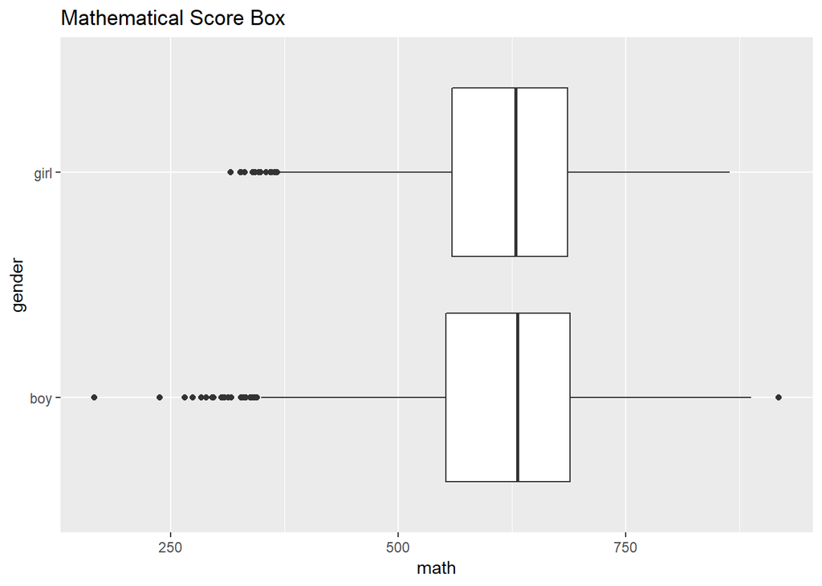

```r
ggplot(data = dta, aes(x = gender, y = math)) +
 geom_boxplot() + coord_flip() +
 labs( y = 'math', x = 'gender',
       title = 'Mathematical Score Box')
```

### 信賴區間

這裡95%的信賴區間由平均數取兩倍標準差而得，男生為612<sub>621，女生為615</sub>623，  
兩者差距不大，甚至女生還略高

```r
#計算95%信賴區間的函式
with(dta,
     tapply(math, gender,
     function(x)
       c(mean(x) + c(-2, 2) * sd(x)/sqrt(length(x)))))
```

```
## $boy
## [1] 612.0913 621.0584
##
## $girl
## [1] 615.4899 623.5705
```

### 用 t-test 檢驗

p-value為0.3273大於0.05，因此性別對成績影響的顯著性不大

```r
#加上參數 var.equal=TRUE 來假設變異數同值(不做Welch校正)
t.test(math ~ gender, data = dta, var.equal = TRUE)
```

```
##
##  Two Sample t-test
##
## data:  math by gender
## t = -0.97969, df = 4465, p-value = 0.3273
## alternative hypothesis: true difference in means is not equal to 0
## 95 percent confidence interval:
##  -8.869280  2.958673
## sample estimates:
##  mean in group boy mean in group girl
##           616.5749           619.5302
```

## 興趣 vs 數學成績

### plot

由圖中可觀察到:興趣越高，成績也越高  
但相同興趣的人，彼此成績的差異也大

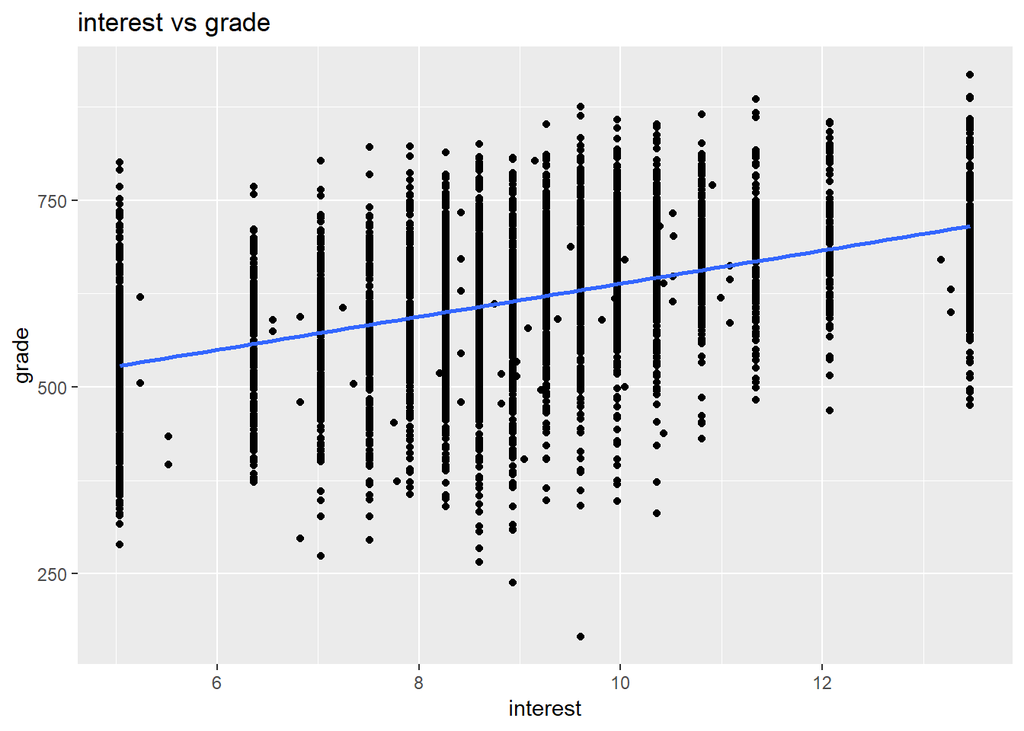

```r
ggplot(data = dta, aes(x = math.interest , y = math)) +
 geom_point() +
 stat_smooth(aes(y = math,x=math.interest), method = 'lm', se=F) + #平均值連線
 labs( y = 'grade', x = 'interest', title = 'interest vs grade')
```

## 投入時間 vs 數學成績

### boxplot

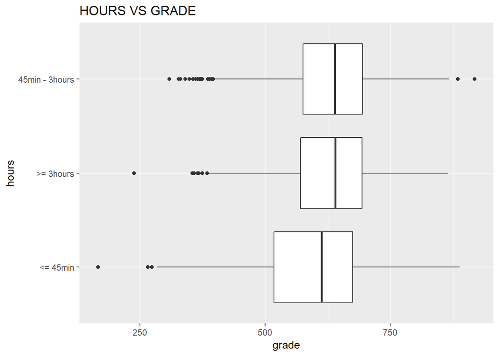

```r
ggplot(data = dta, aes(x = math.hours, y = math)) +
 geom_boxplot() + coord_flip() +
 labs( y = 'grade', x = 'hours',
       title = 'HOURS VS GRADE')
```

### 信賴區間

```r
#計算95%信賴區間的函式
with(dta,
     tapply(math, math.hours,
     function(x)
       c(mean(x) + c(-2, 2) * sd(x)/sqrt(length(x)))))
```

```
## $`<= 45min`
## [1] 591.4573 602.3069
##
## $`>= 3hours`
## [1] 620.9974 634.5710
##
## $`45min - 3hours`
## [1] 627.0650 635.2444
```

## 父母教育 & 教育資源量 vs 數學成績

### 觀察父母的教育背景是否與數學成績有關

#### 利用factor把父母教育欄位的level定下來

次序為小學、國中、高中、大學、及大學以上

```r
dta$parental.education <- factor(dta$parental.education,
                       levels = c('elementary school',
                                  'junior high school',
                                  'high school',
                                  'college',
                                  'university above'))
```

#### 不同父母教育程度下的數學分數平均數

可以發現父母的教育程度對數學分數平均數有所影響，父母教育程度愈高，子女的數學成績平均來說也較高  
但平均並不一定能代表整體分布，因此下面畫分布圖來查看相關

```r
tapply(dta$math, dta$parental.education, mean)
```

```
##  elementary school junior high school        high school
##           536.5940           558.7106           598.8742
##            college   university above
##           645.2816           660.9434
```

```r
library(Hmisc)
```

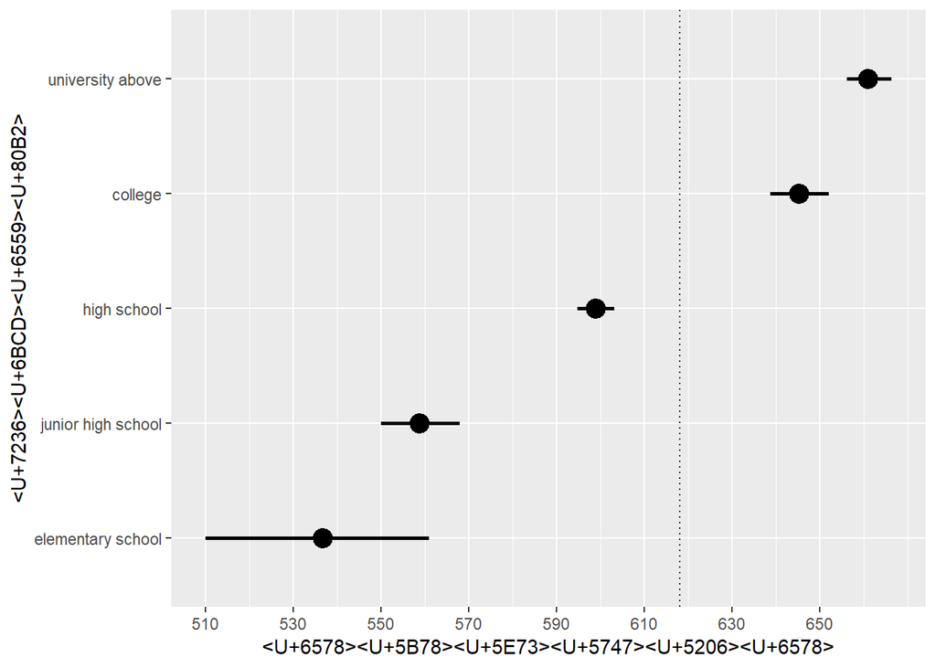

```r
#同父母教育程度下的數學分數平均數，加上信賴區間
ggplot(data = dta, aes(x = parental.education, y = math)) +#選定座標軸資料
  stat_summary(fun.data = 'mean_cl_boot', size = 1) +
  scale_y_continuous(breaks = seq(510, 660, by = 20)) +#限定y座標範圍
  geom_hline(yintercept = mean(dta$math) , linetype = 'dotted') +#boxplot圖標樣式
  labs(x = '父母教育', y = '數學平均分數') +#座標名稱
  coord_flip()#兩軸對調
```

#### 畫圖查看父母教育的效果與教育資源差距關聯性 p-value遠小於0.05，父母教育程度與小孩數學成績有影響

```r
anova(m1 <- lm(math ~ parental.education, data = dta))
```

```
## Analysis of Variance Table
##
## Response: math
##                      Df   Sum Sq Mean Sq F value    Pr(>F)
## parental.education    4  5634301 1408575  158.12 < 2.2e-16 ***
## Residuals          4462 39748578    8908
## ---
## Signif. codes:  0 '***' 0.001 '**' 0.01 '*' 0.05 '.' 0.1 ' ' 1
```

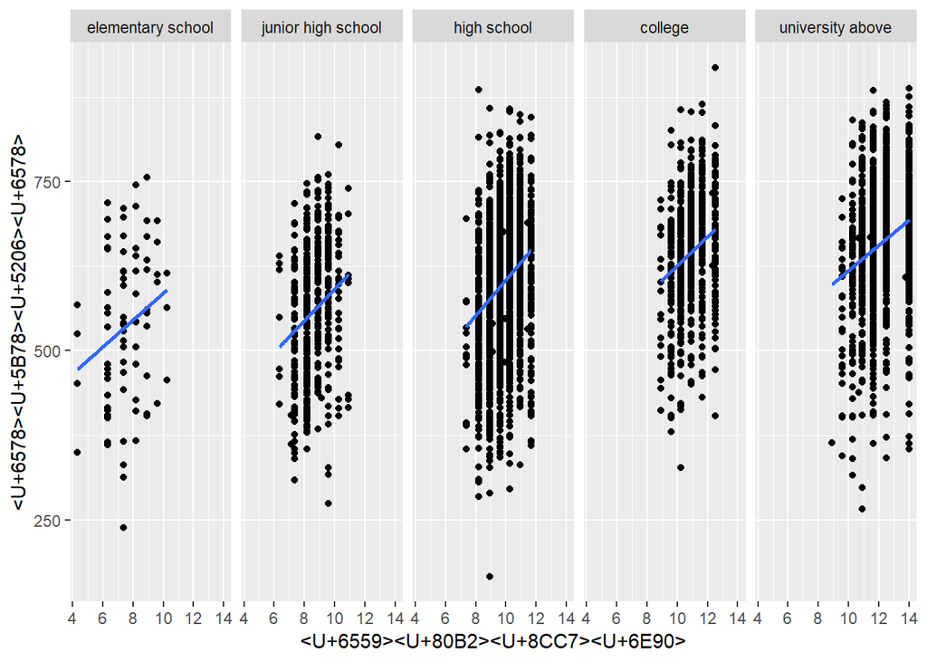

```r
ggplot(data = dta, aes(group = parental.education, y = math, x = educational.resources)) +#選定座標
  geom_point() +#劃出點圖
  stat_smooth(aes(group = parental.education,y = math,x=educational.resources), method = 'lm', se=F) +#平均值連線
  facet_grid( . ~  parental.education) +#依父母教育程度分組
  labs(x = '教育資源', y = '數學分數')#座標軸名稱
```

#### 把教育資源加進模型

p-value遠小於0.05，教育資源與數學成績有影響

```r
anova(m2 <- update(m1, . ~ . +  educational.resources, data = dta))
```

```
## Analysis of Variance Table
##
## Response: math
##                         Df   Sum Sq Mean Sq F value    Pr(>F)
## parental.education       4  5634301 1408575  168.57 < 2.2e-16 ***
## educational.resources    1  2471927 2471927  295.82 < 2.2e-16 ***
## Residuals             4461 37276651    8356
## ---
## Signif. codes:  0 '***' 0.001 '**' 0.01 '*' 0.05 '.' 0.1 ' ' 1
```

#### 把學習興趣加進模型

p-value遠小於0.05，學習興趣與數學成績有影響

```r
anova(m3 <- update(m2, . ~ . +  math.interest, data = dta))
```

```
## Analysis of Variance Table
##
## Response: math
##                         Df   Sum Sq Mean Sq F value    Pr(>F)
## parental.education       4  5634301 1408575  208.56 < 2.2e-16 ***
## educational.resources    1  2471927 2471927  366.00 < 2.2e-16 ***
## math.interest            1  7154280 7154280 1059.28 < 2.2e-16 ***
## Residuals             4460 30122371    6754
## ---
## Signif. codes:  0 '***' 0.001 '**' 0.01 '*' 0.05 '.' 0.1 ' ' 1
```

#### 把學習投入加進模型

p-value小於0.05，學習投入與數學成績有影響

```r
anova(m4 <- update(m3, . ~ . +  math.input, data = dta))
```

```
## Analysis of Variance Table
##
## Response: math
##                         Df   Sum Sq Mean Sq   F value    Pr(>F)
## parental.education       4  5634301 1408575  208.8483 < 2.2e-16 ***
## educational.resources    1  2471927 2471927  366.5106 < 2.2e-16 ***
## math.interest            1  7154280 7154280 1060.7594 < 2.2e-16 ***
## math.input               1    48694   48694    7.2199  0.007237 **
## Residuals             4459 30073677    6744
## ---
## Signif. codes:  0 '***' 0.001 '**' 0.01 '*' 0.05 '.' 0.1 ' ' 1
```

#### 把性別加進模型

p-value小於0.05，性別與數學成績有影響

```r
anova(n5 <- update(m4, . ~ . +  gender , data = dta))
```

```
## Analysis of Variance Table
##
## Response: math
##                         Df   Sum Sq Mean Sq  F value    Pr(>F)
## parental.education       4  5634301 1408575  209.864 < 2.2e-16 ***
## educational.resources    1  2471927 2471927  368.294 < 2.2e-16 ***
## math.interest            1  7154280 7154280 1065.921 < 2.2e-16 ***
## math.input               1    48694   48694    7.255  0.007097 **
## gender                   1   152332  152332   22.696 1.958e-06 ***
## Residuals             4458 29921345    6712
## ---
## Signif. codes:  0 '***' 0.001 '**' 0.01 '*' 0.05 '.' 0.1 ' ' 1
```

#### 把評價加進模型

p-value小於0.05，評價與數學成績有影響

```r
anova(n6 <- update(n5, . ~ . +math.evaluation , data = dta))
```

```
## Analysis of Variance Table
##
## Response: math
##                         Df   Sum Sq Mean Sq  F value    Pr(>F)
## parental.education       4  5634301 1408575  211.139 < 2.2e-16 ***
## educational.resources    1  2471927 2471927  370.530 < 2.2e-16 ***
## math.interest            1  7154280 7154280 1072.392 < 2.2e-16 ***
## math.input               1    48694   48694    7.299  0.006925 **
## gender                   1   152332  152332   22.834 1.823e-06 ***
## math.evaluation          1   187240  187240   28.066 1.229e-07 ***
## Residuals             4457 29734104    6671
## ---
## Signif. codes:  0 '***' 0.001 '**' 0.01 '*' 0.05 '.' 0.1 ' ' 1
```

### 畫圖

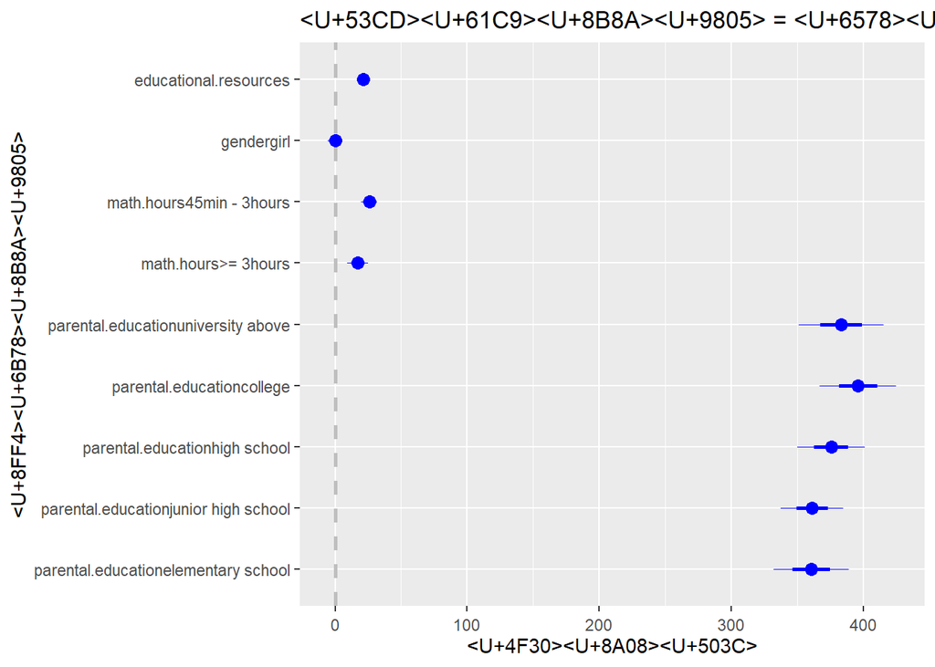

```r
require(coefplot)
m2 <- lm(math ~ parental.education+math.hours+gender+educational.resources -1,
         data = dta)
coefplot(m2, xlab = '估計值', ylab = '迴歸變項', title = '反應變項 = 數學分數')
```

### 把資料與迴歸分析的預測值、殘差與影響度放進資料

```r
fit_m2 <- data.frame(dta[, c(2, 12, 13)], fitted = fitted(m2), resid = resid(m2),
                     infl = influence(m2)$hat )
```

### 依父母教育疊合真實觀測值與預測值

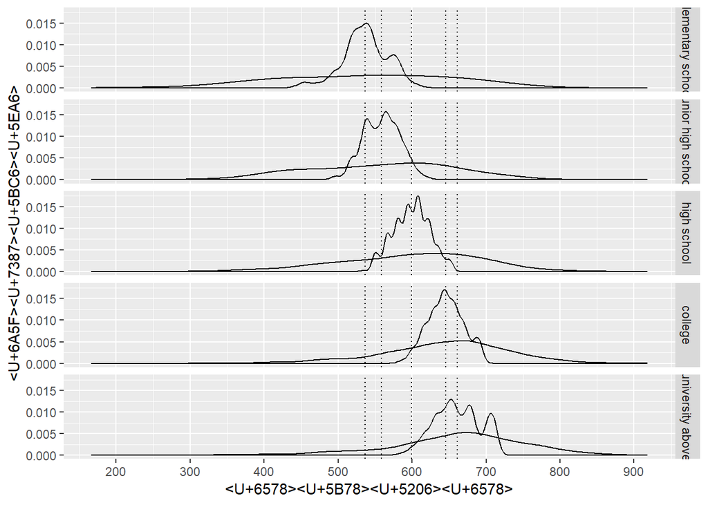

```r
ggplot(data = fit_m2, aes(x = math, group = parental.education )) +
 stat_density(geom = 'path', position = 'identity') +
 stat_density(geom = 'path', position = 'identity', aes(x = fitted)) +
 geom_vline(xintercept = c(with(dta, tapply(math,parental.education, mean))), linetype = 'dotted')+
 facet_grid(parental.education ~ .) +
 scale_x_continuous(breaks = seq(200, 900, by = 100))+
 labs(x = '數學分數', y = '機率密度')
```

### 看殘差分配，依父母教育，檢視常態與變異數同質假設

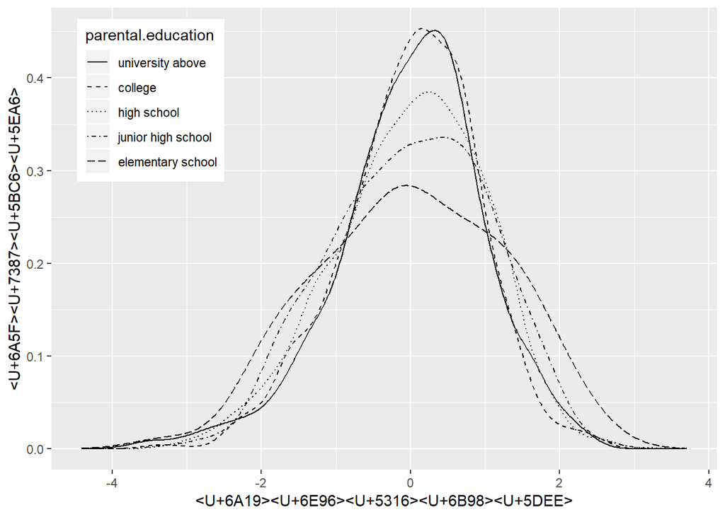

```r
ggplot(data = fit_m2, aes(x = scale(resid)), group = parental.education ) +
 stat_density(geom = 'path', position = 'identity', aes(linetype = parental.education)) +
 scale_linetype_manual(values = 5:1) +
 guides(linetype = guide_legend(reverse = TRUE)) +
 labs(x = '標準化殘差', y = '機率密度') +
 theme(legend.position = c(.15, .8))
```

### 看看殘差的 Q-Q 圖，依父母教育。檢視常態假設

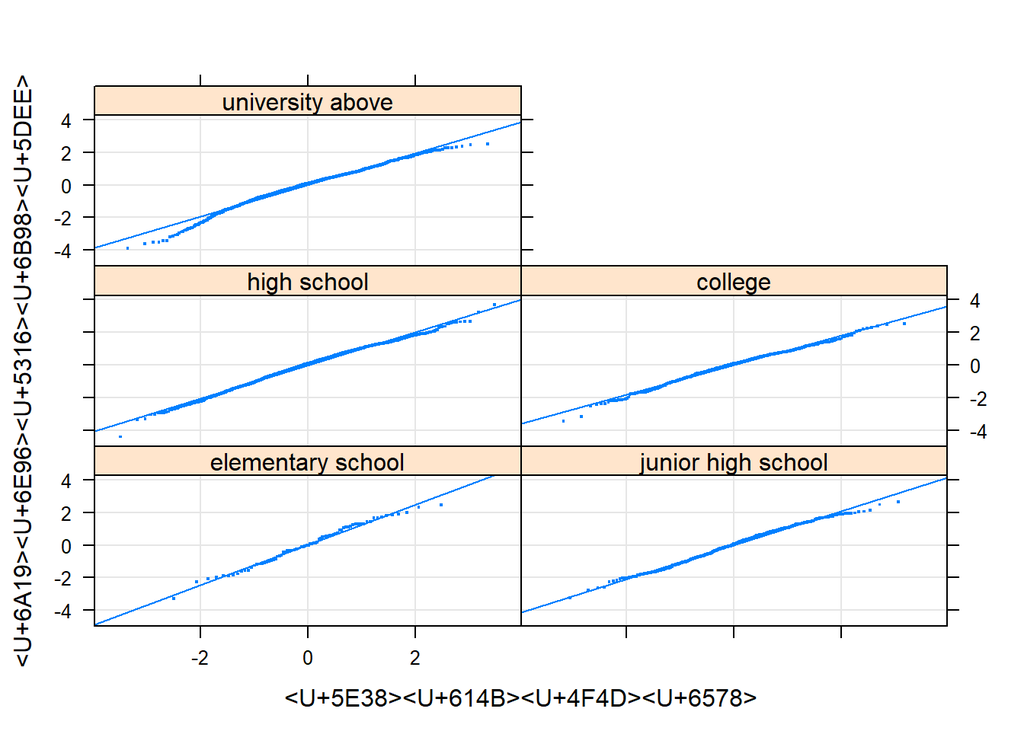

```r
require(lattice)
qqmath(~ scale(resid) | parental.education, data = fit_m2, type = c('p', 'g', 'r'),
       xlab = '常態位數', ylab = '標準化殘差', layout = c(2, 3),
       pch = '.', cex = 2)
```

### 畫預測值與殘差的散佈圖，檢查線性與等分散假設

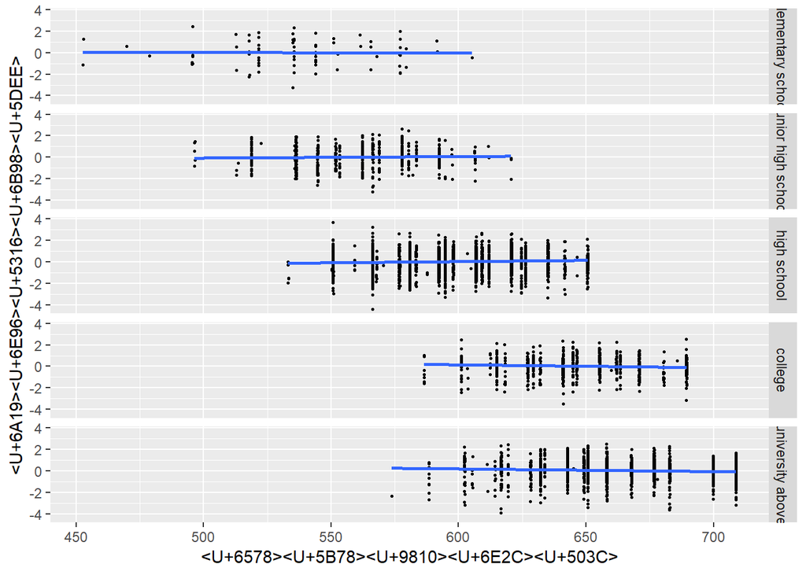

```r
require(MASS)
ggplot(data = fit_m2, aes(x = fitted, y = scale(resid), group = parental.education )) +
  geom_point(pch = 20, size = 1) +
  stat_smooth(method = 'rlm', se = F) +
  facet_grid(parental.education ~ .) +
  labs(x = '數學預測值', y = '標準化殘差')
```

### 呈現影響值（影響估計結果過大的值）與標準化殘差

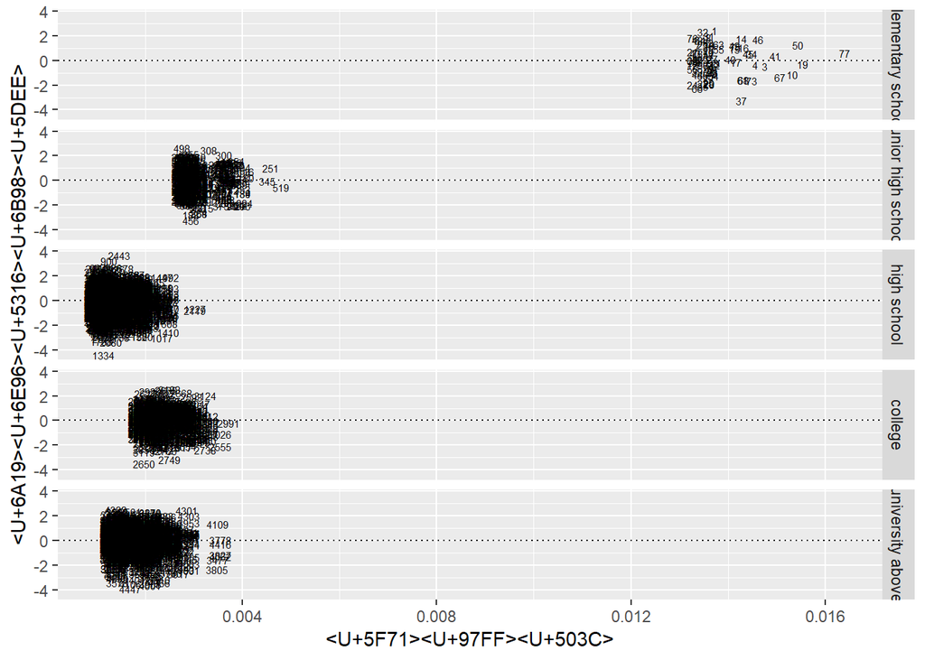

```r
ggplot(data = fit_m2, aes(x = infl, y = scale(resid), group = parental.education)) +
 geom_text(aes(label = rownames(fit_m2)), cex = 2) +
 geom_hline(yintercept = 0, linetype = 'dotted') +
 facet_grid(parental.education ~ .) +
 labs(x = '影響值', y = '標準化殘差')
```

### 看看影響值

```r
summary(influence(m2)$hat)
```

```
##     Min.  1st Qu.   Median     Mean  3rd Qu.     Max.
## 0.000972 0.001217 0.001748 0.002015 0.002239 0.016395
```

## 那些變項是否和數學成績最相關

### 內在歸因

此分類為與個人學習意願相關的，包含興趣、投入與評價  
估計值相較於實際值來說過於集中，準確度還是不夠高

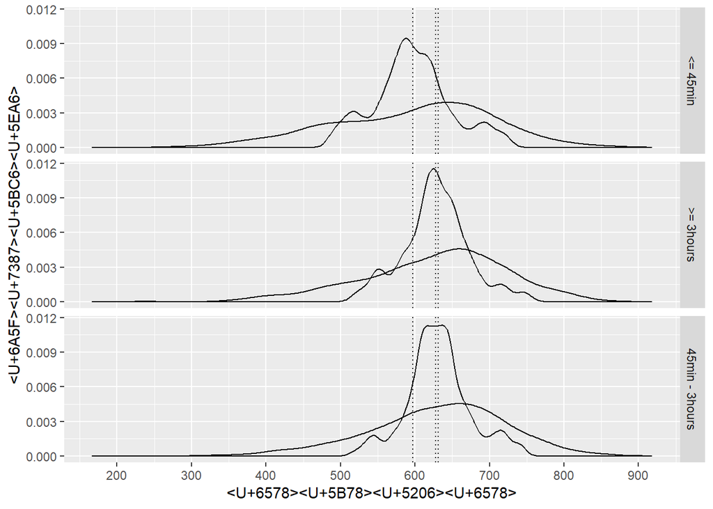

```r
m5 <- lm(math ~ math.interest + math.hours+math.input+math.evaluation, data = dta)

fit_m5 <- data.frame(dta[, c(2, 3, 6,5,4)], fitted = fitted(m5), resid = resid(m5), infl = influence(m5)$hat)

ggplot(data = fit_m5, aes(x = math, group = math.hours )) +
 stat_density(geom = 'path', position = 'identity') +
 stat_density(geom = 'path', position = 'identity', aes(x = fitted)) +
 geom_vline(xintercept = c(with(dta, tapply(math, math.hours, mean))), linetype = 'dotted')+
 facet_grid(math.hours ~ .) +
 scale_x_continuous(breaks = seq(200, 900, by = 100))+
 labs(x = '數學分數', y = '機率密度')
```

### 外在歸因

此分類為與個人出生相關的，包含父母教育程度與教育資源  
估計值相較於實際值來說依舊集中，仍無法完全接近實際狀況

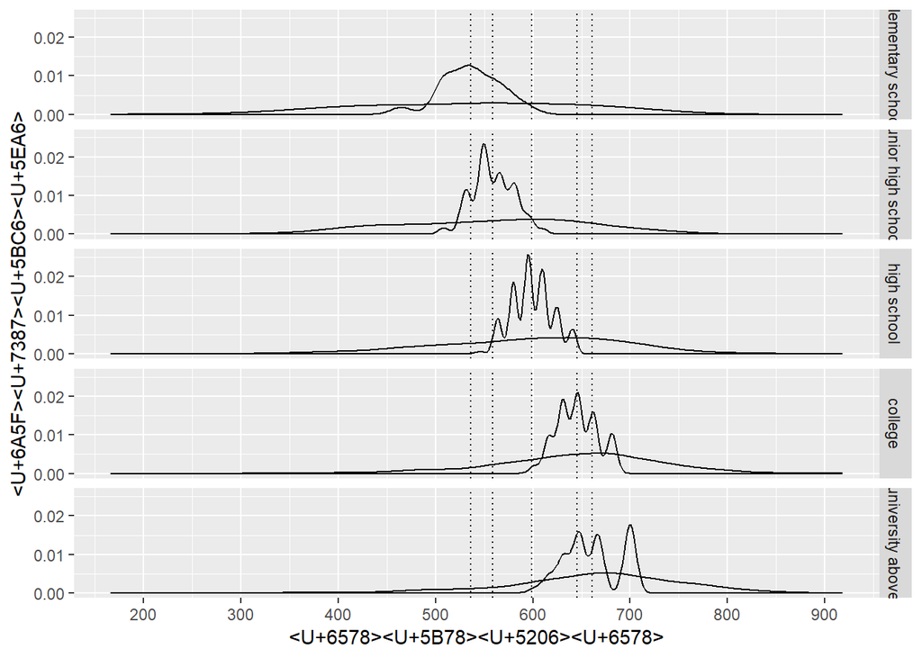

```r
m6 <- lm(math ~ educational.resources+parental.education , data = dta)

fit_m6 <- data.frame(dta[, c(2, 13,12)], fitted = fitted(m6), resid = resid(m6), infl = influence(m6)$hat)

ggplot(data = fit_m6, aes(x = math, group = parental.education )) +
 stat_density(geom = 'path', position = 'identity') +
 stat_density(geom = 'path', position = 'identity', aes(x = fitted)) +
 geom_vline(xintercept = c(with(dta, tapply(math, parental.education, mean))), linetype = 'dotted')+
 facet_grid(parental.education ~ .) +
 scale_x_continuous(breaks = seq(200, 900, by = 100))+
 labs(x = '數學分數', y = '機率密度')
```

### 綜合因素

此資料為估計興趣、時間、教育資源與父母教育程度對成績的影響，  
由於在前面的統計中，這幾項與成績呈正相關，且相關程度較高，因此選取這幾項  
而這幾項資料綜合起來的估計也較前述兩者準確  
從以上圖表我們可推論，影響個人成績高低的因素有興趣、父母教育程度與教育資源，但其實或許還有其他因素，只是這三種的影響力較大

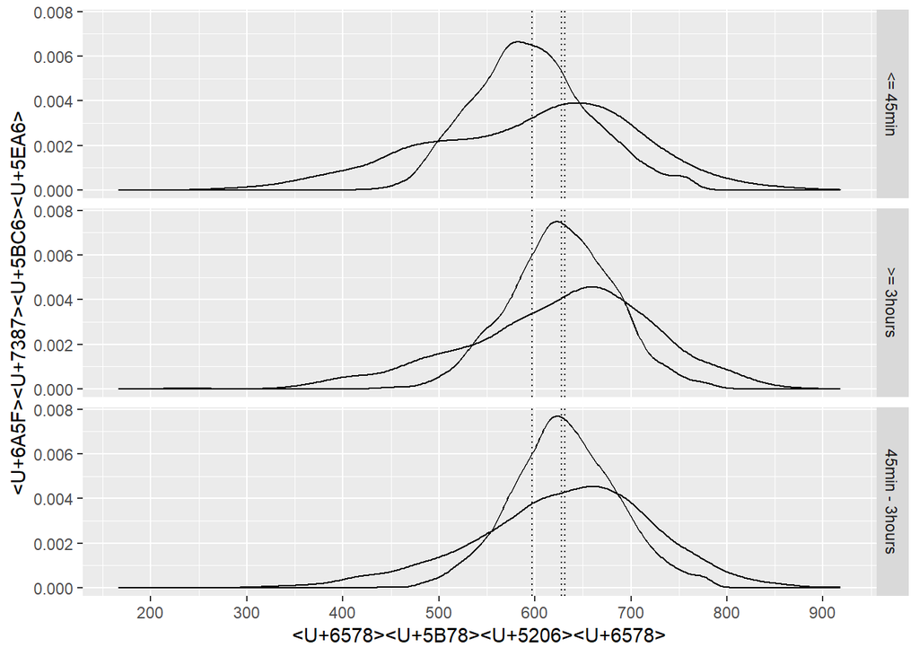

```r
m7 <- lm(math ~ math.interest + math.hours  + educational.resources+parental.education, data = dta)

fit_m7 <- data.frame(dta[, c(2,3,6,13,12)], fitted = fitted(m7), resid = resid(m7), infl = influence(m7)$hat)

ggplot(data = fit_m7, aes(x = math, group = math.hours )) +
 stat_density(geom = 'path', position = 'identity') +
 stat_density(geom = 'path', position = 'identity', aes(x = fitted)) +
 geom_vline(xintercept = c(with(dta, tapply(math, math.hours, mean))), linetype = 'dotted')+
 facet_grid(math.hours ~ .) +
 scale_x_continuous(breaks = seq(200, 900, by = 100))+
 labs(x = '數學分數', y = '機率密度')
```